# Section Assignment 8

2/26/25

Things-to-Note: - 1) Don’t rename external files or edit them in any way 2) Don’t change the variable names 3) Don’t destroy or overwrite any variables 4) Don’t use global path in your script. Instead use “setwd()” interactively in the console, but don’t include this code in your submission

If you don’t take above instructions into account it might effect your grades. *** Your Information: -

```r
firstname <- "Zakir"   # example: "Liam"
lastname <- "Alibhai"  # example: "Mueller"
username <- "zalibhai"  #example: "lomueller"   Do not include the "@ucsd.edu" part!
```

Please Read!

Does learning a second language change brain structure? Machelli et al.(2004)* tested 22 native Italian speakers who had learned English as a second language. Proficiency in reading, writing, and speech were assessed by a proficiency score. Gray matter density was measured in the left inferior parietal region of the brain using a neuroimaging technique, as mm^3 of gray matter per voxel.

- Machelli et al.(2004) Structural plasticity in the bilingual brain. Nature 431:757 https://doi.org/10.1038/431757a

You will find the data from their study in the “Week8Brains.csv” file on Canvas.

Since we have already downloaded and installed the necessary packages, this week, simply load the tidyverse functions into your working library:

Just like last week, this week you will practice answering a research question step by step. Think of it as practice for your term project!

Step 1. Import your data, and check the assumption of normality.

Question 1: Import the data you downloaded from canvas this week (File name should be: “Week8Brains.csv”).

```r
BrainData<-read.csv(file = "Week8Brains.csv")
head(BrainData)
```

```
##   Second.language.proficiency Gray.matter.density
## 1                        0.26              -0.070
## 2                        0.44              -0.080
## 3                        0.89              -0.008
## 4                        1.26              -0.009
## 5                        1.69              -0.023
## 6                        1.97              -0.009
```

```r
### This chunk of code is for grading purposes.
### Don't change/delete this chunk of code.
q1 <- BrainData
```

Question 2-3: Use visualizations and tests to determine that the data are normally distributed. Yes, you will have to do this twice. Please make your histograms in ggplot

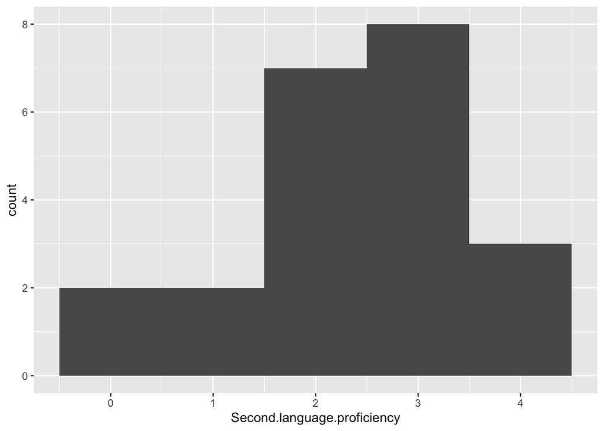

```r
#visualize the second language scores data here.
Histogram1<-ggplot(data = BrainData, mapping = aes(x=Second.language.proficiency)) +
  geom_histogram(binwidth = 1)
Histogram1
```

```r
#Test for normality of the second language scores in this code box.
ks.test(BrainData$Second.language.proficiency,"pnorm",mean(BrainData$Second.language.proficiency),sd(BrainData$Second.language.proficiency))
```

```
##
##  Asymptotic one-sample Kolmogorov-Smirnov test
##
## data:  BrainData$Second.language.proficiency
## D = 0.13079, p-value = 0.846
## alternative hypothesis: two-sided
```

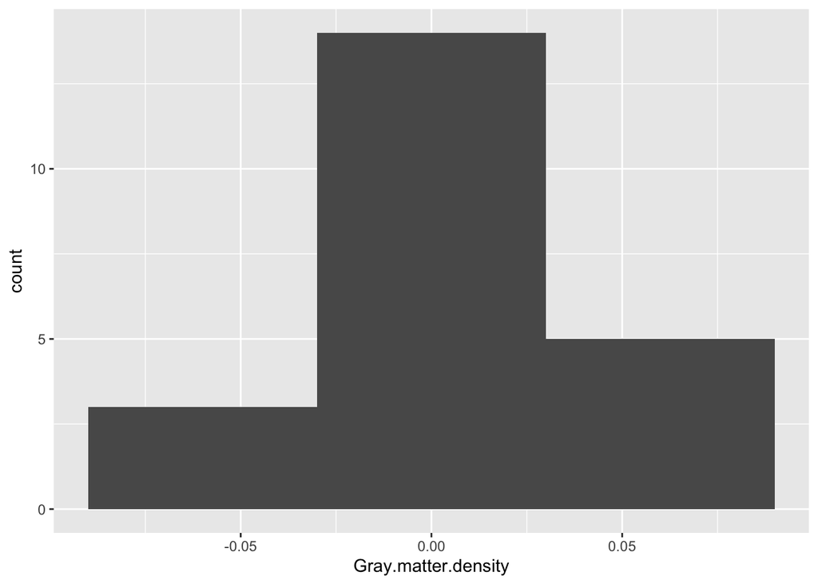

```r
#visualize the gray matter density data here.
Histogram2<-ggplot(data = BrainData, mapping = aes(x=Gray.matter.density)) +
  geom_histogram(binwidth = 0.06)
Histogram2
```

```r
#Test for normality of the gray matter density data in this code box.
ks.test(BrainData$Gray.matter.density,"pnorm",mean(BrainData$Gray.matter.density),sd(BrainData$Gray.matter.density))
```

```
##
##  Asymptotic one-sample Kolmogorov-Smirnov test
##
## data:  BrainData$Gray.matter.density
## D = 0.15955, p-value = 0.6299
## alternative hypothesis: two-sided
```

```r
### This chunk of code is for grading purposes.
### Don't change/delete this chunk of code.
q2 <- Histogram1
q3 <- Histogram2
```

Question 4: Are the second language scores data normally distributed? Answer with a simple TURE or FLASE, no other text required.

```r
q4 <- "TRUE"
```

Question 5: Are the gray matter density data normally distributed? Answer with a simple TURE or FLASE, no other text required.

```r
q5 <- "TRUE"
```

Step 2. Identify your null and alternate hypotheses, generate the correct linear model, test the null hypothesis.

Research question: Does learning a second language change brain structure?

Question 6-7: What is the null and alternate hypothesis that answer the research question? To prepare you for the final, think about how you could answer this as an equation.

```r
NullHypothesis<-"There is no change or difference in brain structure between individuals who learn a second language and those who do not."
print(NullHypothesis)
```

```
## [1] "There is no change or difference in brain structure between individuals who learn a second language and those who do not."
```

```r
AlternateHypothesis<-"There is a change or difference in brain structure between individuals who learn a second language and those who do not."
print(AlternateHypothesis)
```

```
## [1] "There is a change or difference in brain structure between individuals who learn a second language and those who do not."
```

```r
### This chunk of code is for grading purposes.
### Don't change/delete this chunk of code.
q6 <- NullHypothesis
q7 <- AlternateHypothesis
```

Question 8: Generate a linear model to model the relationship in the data. Consult the lecture notes for code.

```r
#Build your linear model in this code block
q8 <- lm(Gray.matter.density ~ Second.language.proficiency, data = BrainData)
q8
```

```
##
## Call:
## lm(formula = Gray.matter.density ~ Second.language.proficiency,
##     data = BrainData)
##
## Coefficients:
##                 (Intercept)  Second.language.proficiency
##                    -0.07214                      0.03024
```

Question 9: Now that you have the slope and intercept estimates for your model, write out the linear equation that predicts Y. Use the column names for X and Y

```r
q9 <- "Gray.matter.density = 0.03024(Second.language.proficiency) - 0.07214"
```

Question 10: Perform a null hypothesis test of the model you generated. Try using summary() instead of anova() this week.

```r
#test your linear model in this code block
q10 <-summary(q8)
q10
```

```
##
## Call:
## lm(formula = Gray.matter.density ~ Second.language.proficiency,
##     data = BrainData)
##
## Residuals:
##       Min        1Q    Median        3Q       Max
## -0.032123 -0.020623 -0.001865  0.017059  0.037232
##
## Coefficients:
##                              Estimate Std. Error t value Pr(>|t|)
## (Intercept)                 -0.072142   0.012309  -5.861 9.84e-06 ***
## Second.language.proficiency  0.030235   0.004749   6.367 3.26e-06 ***
## ---
## Signif. codes:  0 '***' 0.001 '**' 0.01 '*' 0.05 '.' 0.1 ' ' 1
##
## Residual standard error: 0.02183 on 20 degrees of freedom
## Multiple R-squared:  0.6696, Adjusted R-squared:  0.6531
## F-statistic: 40.54 on 1 and 20 DF,  p-value: 3.264e-06
```

Question 11-14: Extract the important information about your model. Type in numbers: the slope, the standard error of the slope, the p value that tests the null, and the r squared value.

```r
q11 <-  0.030235  #Slope value before the hashtag
q12 <-  0.004749  #Standard error of the slope before the hashtag
q13 <-  3.26e-06  #Correct p value before the hashtag
q14 <-  0.6696  #R^2 before the hashtag
```

Step 3. Graphical representation of the model.

Question 15: Generate a figure representing the data, your model and the error around your model. Use my example as a template. Drawing a line of best fit can be done a bunch of ways in ggplot, but I recommend looking into how to use the `geom_smooth()` function as it can also create the shaded error on the graph, which is required to get full credit. Don’t worry about matching the colors to the example, in fact I encourage you to look up all the different color options in R and find a color scheme you like! Some hints to help you: 1) The size of the points is larger than the default. 2) The axis text for both x and y is increased. 3) The x and y axis need to be relabeled.

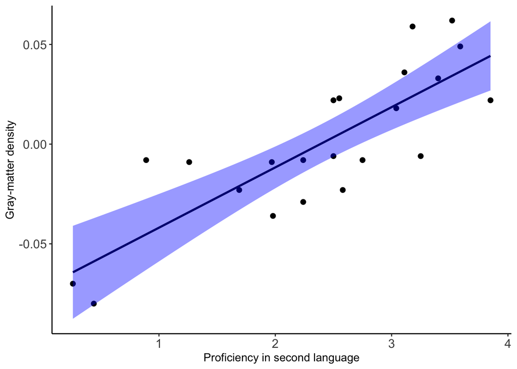

```r
plot1<-ggplot(data=BrainData,mapping=aes(x=Second.language.proficiency,y=Gray.matter.density))+
  theme_classic() +
  theme(axis.text=element_text(size=12)) +
  xlab("Proficiency in second language") +
  ylab("Gray-matter density") +
  geom_point(size=2) +
  geom_smooth(method = lm,color="navy",fill="blue")
plot1
```

```r
### This chunk of code is for grading purposes.
### Don't change/delete this chunk of code.
q15 <- plot1
```

Part 2: A question on correlation: In the scenario above, the scientists were confident that they had an independent and dependent variable. What if we did not share that opinion? Reanalyze the brain data using a correlative model instead.

We will assume the data are normally distributed, you already tested this in Q2.

Question 16: Test the null hypothesis of a correlation. Consult the lecture notes for code associated with performing correlation hypothesis testing in R.

```r
q16<-cor.test(BrainData$Second.language.proficiency,BrainData$Gray.matter.density)
q16
```

```
##
##  Pearson's product-moment correlation
##
## data:  BrainData$Second.language.proficiency and BrainData$Gray.matter.density
## t = 6.3671, df = 20, p-value = 3.264e-06
## alternative hypothesis: true correlation is not equal to 0
## 95 percent confidence interval:
##  0.6056638 0.9218696
## sample estimates:
##       cor
## 0.8183134
```

Once you are done, make sure there are no errors. Save the .rmd file with your name and the week number in the file name:

(for example: “Liam_Mueller_Section_Assignment_8.rmd”).

Then upload this rmd file to canvas under the Week 8 Section Assignemnt before the deadline.